# EDA - In-Class Lab Exercise (Day 3) - Solutions [V2.0 - 270320]

|  | Inclass - Lab (Day 3) |
| --- | --- |

### About the dataset (Adult Income Data)

The dataset contains information about the individuals' age, gender, and several attributes affecting the income of a person.  
Attribute information:

**age:** Age of an individual

**workclass:** Working class of the individual

**fnlwgt:** Weights based on the demographic characteristics

**education:** Highest education of the individual

**education.num:** Education encoded with unique numbers

**marital.status:** Marital status of the individual

**occupation:** Occupation of the individual

**relationship:** Relation of the individual in the family

**race:** Race of the individual

**sex:** Gender of the individual

**capital.gain:** Gain amount of the individual

**capital.loss:** Loss amount of the individual

**hours.per.week:** Working hours per week

**native.country:** The native country of the individual

**income:** Income of the individual

## Table of Content

1. **Quantitative and Quantitative Analysis**
2. **Categorical and Quantitative Analysis**
3. **Categorical and Categorical Analysis**

**Import the required libraries**

```python
# import pandas
import pandas as pd

# import numpy
import numpy as np

# import matplotlib.pyplot
import matplotlib.pyplot as plt

# import seaborn
import seaborn as sns

# to suppress the warnings
import warnings
warnings.filterwarnings('ignore')
```

#### Load the adult dataset and check the first five observations

```python
# load the csv file
df_adult = pd.read_csv('adult.csv')

# display the first five observations
df_adult.head()
```

|  | age | workclass | fnlwgt | education | education.num | marital.status | occupation | relationship | race | sex | capital.gain | capital.loss | hours.per.week | native.country | income |
| --- | --- | --- | --- | --- | --- | --- | --- | --- | --- | --- | --- | --- | --- | --- | --- |
| 0 | 90 | ? | 77053 | HS-grad | 9 | Widowed | ? | Not-in-family | White | Female | 0 | 4356 | 40 | United-States | <=50K |
| 1 | 82 | Private | 132870 | HS-grad | 9 | Widowed | Exec-managerial | Not-in-family | White | Female | 0 | 4356 | 18 | United-States | <=50K |
| 2 | 66 | ? | 186061 | Some-college | 10 | Widowed | ? | Unmarried | Black | Female | 0 | 4356 | 40 | United-States | <=50K |
| 3 | 54 | Private | 140359 | 7th-8th | 4 | Divorced | Machine-op-inspct | Unmarried | White | Female | 0 | 3900 | 40 | United-States | <=50K |
| 4 | 41 | Private | 264663 | Some-college | 10 | Separated | Prof-specialty | Own-child | White | Female | 0 | 3900 | 40 | United-States | <=50K |

### Let's begin with some hands-on practice exercises

## 1. Quantitative and Quantitative Analysis

|  | **1. Is there any effect of a person's age on the working hours** |
| --- | --- |

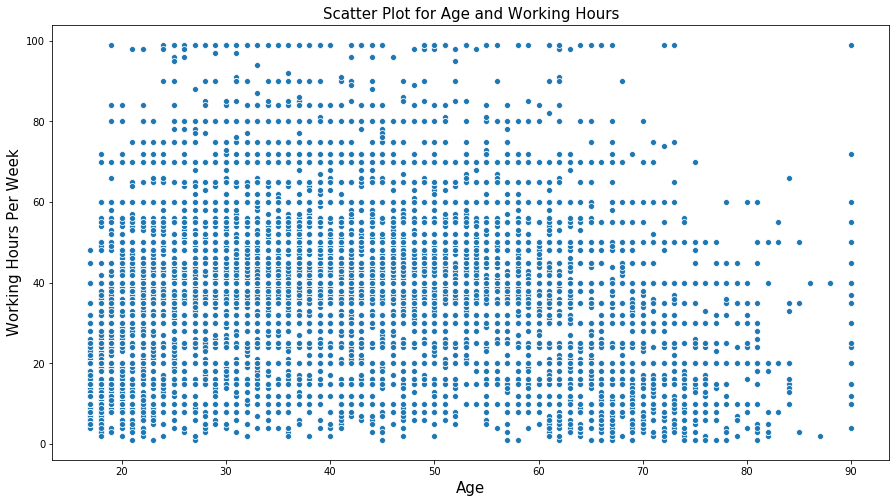

```python
# set the figure size
plt.figure(figsize = (15,8))

# plot a scatter plot to check the relationship
sns.scatterplot(df_adult['age'], df_adult['hours.per.week'])

# add plot and axes labels
# set text size using 'fontsize'
plt.title('Scatter Plot for Age and Working Hours', fontsize = 15)
plt.xlabel('Age', fontsize = 15)
plt.ylabel('Working Hours Per Week', fontsize = 15)

# display the plot
plt.show()
```

The scatter plot shows no specific relationship between the age of a person and the number of working hours. There is an extreme observation of age nearly 90 years corresponding to 100 working hours.

|  | **2. Analyze the trend of the capital gain amount for different educational qualifications** |
| --- | --- |

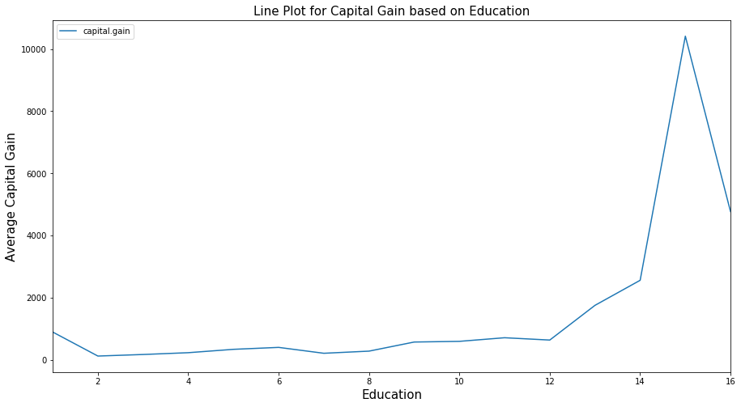

```python
# compute average of 'capital.gain' for unique educational number using groupby()
df_adult[['capital.gain', 'education.num']].groupby('education.num').mean().plot(figsize = (15,8))

# add plot and axes labels
# set text size using 'fontsize'
plt.title('Line Plot for Capital Gain based on Education', fontsize = 15)
plt.xlabel('Education', fontsize = 15)
plt.ylabel('Average Capital Gain', fontsize = 15)

# display the plot
plt.show()
```

The above line plot shows how education affects the capital gain. The highest average gain amount is for individuals with education number 15.

|  | **3. Check the effect of working hours of individuals on capital gain** |
| --- | --- |

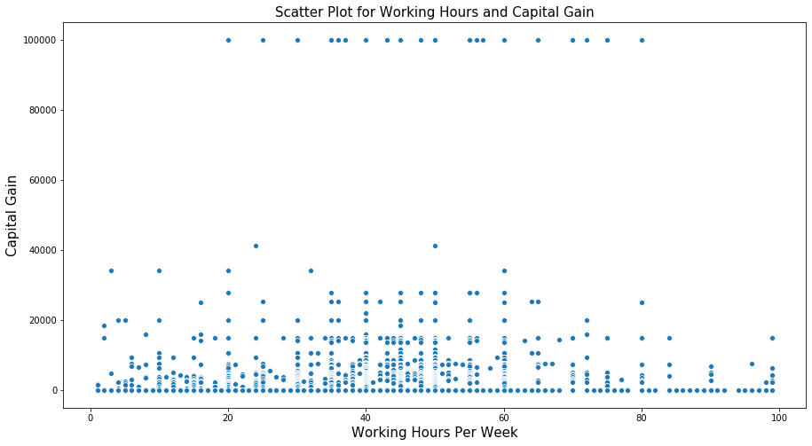

```python
# set the figure size
plt.figure(figsize = (15,8))

# plot a scatter plot to check the relationship
sns.scatterplot(df_adult['hours.per.week'], df_adult['capital.gain'])

# add plot and axes labels
# set font size using 'fontsize'
plt.title('Scatter Plot for Working Hours and Capital Gain', fontsize = 15)
plt.xlabel('Working Hours Per Week', fontsize = 15)
plt.ylabel('Capital Gain', fontsize = 15)

# display the plot
plt.show()
```

The scatter plot shows the presence of extreme points for the capital gain of 100000.

|  | **4. Find the trend in the average working hours corresponding to the age of an individual** |
| --- | --- |

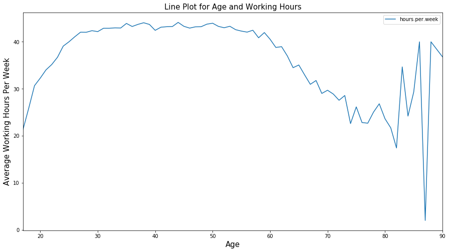

```python
# compute average working hours per week for age using groupby()
df_adult[['age', 'hours.per.week']].groupby('age').mean().plot(figsize = (15,8))

# add plot and axes labels
# set text size using 'fontsize'
plt.title('Line Plot for Age and Working Hours', fontsize = 15)
plt.xlabel('Age', fontsize = 15)
plt.ylabel('Average Working Hours Per Week', fontsize = 15)

# display the plot
plt.show()
```

The line plot shows that the average working hours are increasing with age. After 60 years of age, the working hours are decreasing. It also shows that some older individuals with age between 80 to 90 years are working for more than 30 hours.

|  | **5. Check the distribution of the average capital loss corresponding to the age** |
| --- | --- |

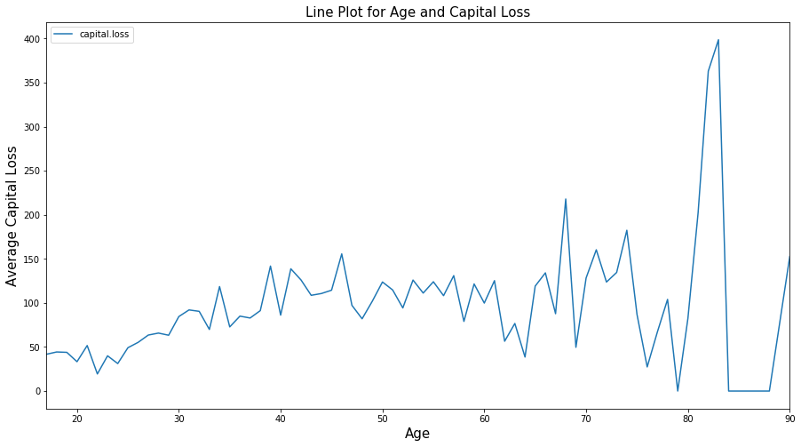

```python
# compute average capital loss for unique age using groupby()
df_adult[['age', 'capital.loss']].groupby('age').mean().plot(figsize = (15,8))

# add plot and axes labels
# set text size using 'fontsize'
plt.title('Line Plot for Age and Capital Loss', fontsize = 15)
plt.xlabel('Age', fontsize = 15)
plt.ylabel('Average Capital Loss', fontsize = 15)

# display the plot
plt.show()
```

The line plot shows that, for the individuals with age 80 to 85 years, there is a sudden hike in the capital loss.

|  | **6. Is there a negative relation between capital gain and age?** |
| --- | --- |

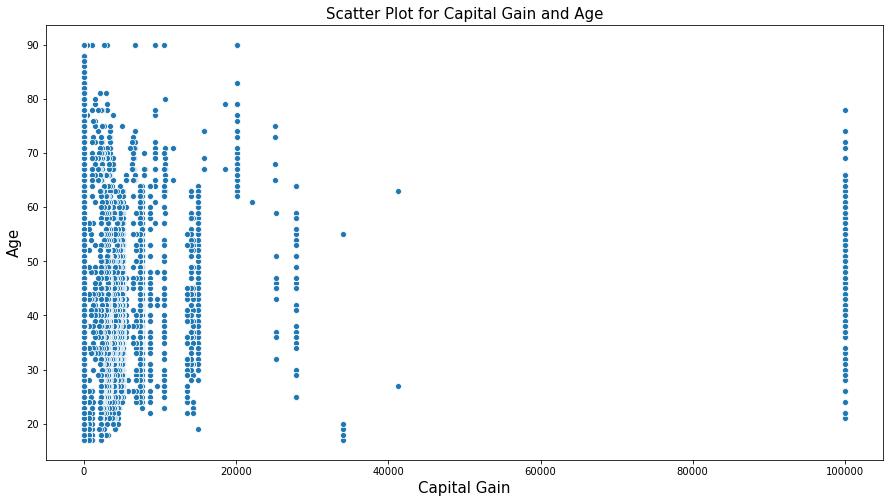

```python
# set the figure size
plt.figure(figsize = (15,8))

# plot a sctter plot
sns.scatterplot(df_adult['capital.gain'], df_adult['age'])

# add plot and axes labels
# set text size using 'fontsize'
plt.title('Scatter Plot for Capital Gain and Age', fontsize = 15)
plt.xlabel('Capital Gain', fontsize = 15)
plt.ylabel('Age', fontsize = 15)

# display the plot
plt.show()
```

No. From the above plot we see that there is no correlation between capital gain and age.

## 2. Categorical and Quantitative Analysis

|  | **7. Compare the average age with levels of income** |
| --- | --- |

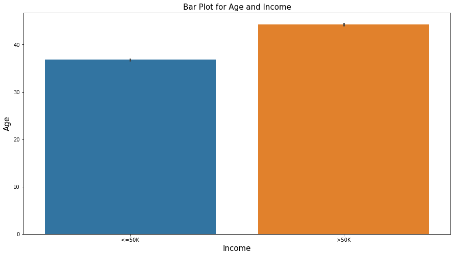

```python
# set the figure size
plt.figure(figsize = (15,8))

# plot a barplot with mean age on y-axis and income on x-axis
sns.barplot(x = 'income', y = 'age', data = df_adult)

# add plot and axes labels
# set text size using 'fontsize'
plt.title('Bar Plot for Age and Income', fontsize = 15)
plt.xlabel('Income', fontsize = 15)
plt.ylabel('Age', fontsize = 15)

# display the plot
plt.show()
```

The barplot shows that the income is greater than 50k for the individuals above 40 years; as, the people with higher age will have a high experience and more income.

|  | **8. Check the distribution of working hours with respect to the gender of the individual** |
| --- | --- |

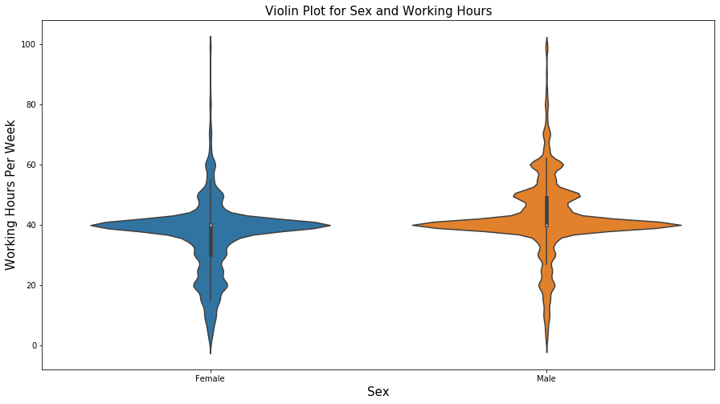

```python
# set the figure size
plt.figure(figsize = (15,8))

# plot a violin plot
sns.violinplot(x = 'sex', y = 'hours.per.week', data = df_adult)

# add plot and axes labels
# set text size using 'fontsize'
plt.title('Violin Plot for Sex and Working Hours', fontsize = 15)
plt.xlabel('Sex', fontsize = 15)
plt.ylabel('Working Hours Per Week', fontsize = 15)

# display the plot
plt.show()
```

For large proportion of females the working hours are between 20 to 50 hours per week. Males have longer working hours (40 to 60 hours per week).

|  | **9. Compare the income of individuals based on their education** |
| --- | --- |

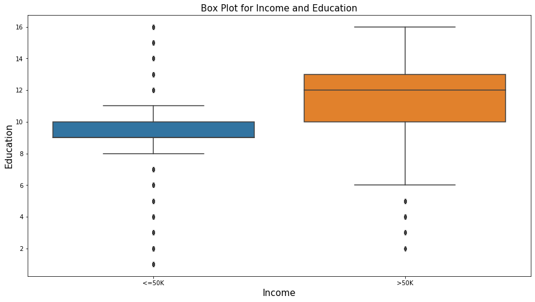

```python
# set the figure size
plt.figure(figsize = (15,8))

# plot the boxplot
sns.boxplot(x = 'income', y = 'education.num', data = df_adult)

# add plot and axes labels
# set text size using 'fontsize'
plt.title('Box Plot for Income and Education', fontsize = 15)
plt.xlabel('Income', fontsize = 15)
plt.ylabel('Education', fontsize = 15)

# display the plot
plt.show()
```

The salary is greater than 50k for the individuals with higher education. The outliers are present for both the categories of income.

|  | **10. Find the average age of males and females** |
| --- | --- |

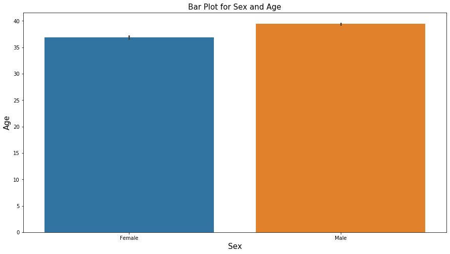

```python
# set the figure size
plt.figure(figsize = (15,8))

# plot a barplot with mean age on y-axis and sex on x-axis
sns.barplot(x = 'sex', y = 'age', data = df_adult)

# add plot and axes labels
# set text size using 'fontsize'
plt.title('Bar Plot for Sex and Age', fontsize = 15)
plt.xlabel('Sex', fontsize = 15)
plt.ylabel('Age', fontsize = 15)

# display the plot
plt.show()
```

The average age of females in the dataset is approximately 36 years, and average age of males is approximately 39 years.

|  | **11. Compare the distribution of working hours for the distinct classes of income** |
| --- | --- |

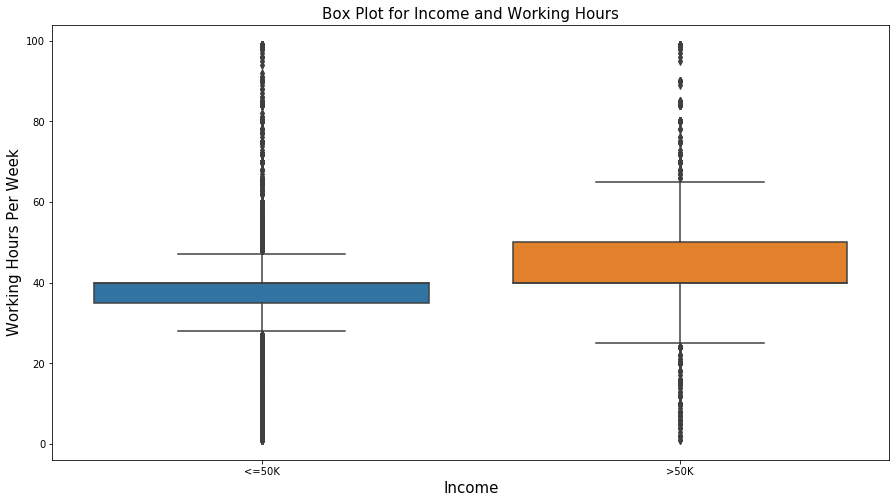

```python
# set the figure size
plt.figure(figsize = (15,8))

# plot the boxplot
sns.boxplot(x = 'income', y = 'hours.per.week', data = df_adult)

# add plot and axes labels
# set text size using 'fontsize'
plt.title('Box Plot for Income and Working Hours', fontsize = 15)
plt.xlabel('Income', fontsize = 15)
plt.ylabel('Working Hours Per Week', fontsize = 15)

# display the plot
plt.show()
```

There is a difference between the working hours based on the income. Also, both the boxplots shows the presence of outliers.

|  | **12. Identify the positively skewed distributions of age based on the gender and race of the individual** |
| --- | --- |

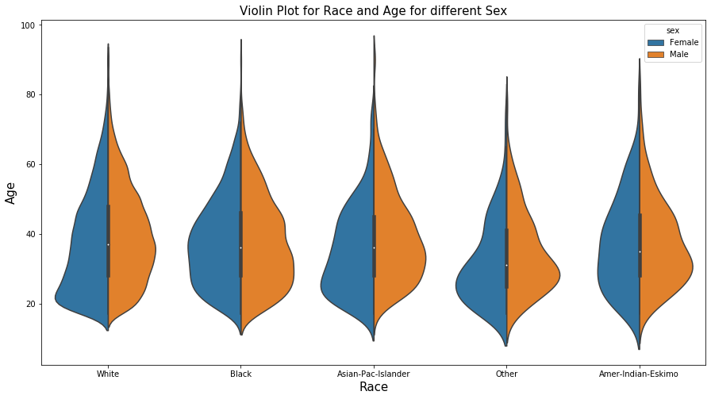

```python
# set the figure size
plt.figure(figsize = (15,8))

# plot a violin plot
# 'split' returns a single violin plot with two categories
sns.violinplot(x = 'race', y = 'age', data = df_adult, hue = 'sex', split = 'sex')

# add plot and axes labels
# set text size using 'fontsize'
plt.title('Violin Plot for Race and Age for different Sex', fontsize = 15)
plt.xlabel('Race', fontsize = 15)
plt.ylabel('Age', fontsize = 15)

# display the plot
plt.show()
```

The above plot shows the positive distribution for pairs given below:

| Distribution | Race, Gender |
| --- | --- |
| Positive Distribution | (White, Female), (Asian-Pac-Islander, Female), (Other, Female), (Other, Male), (Amer-Indian-Eskimo, Male) |

|  | **13. Compare the working hours for each working class** |
| --- | --- |

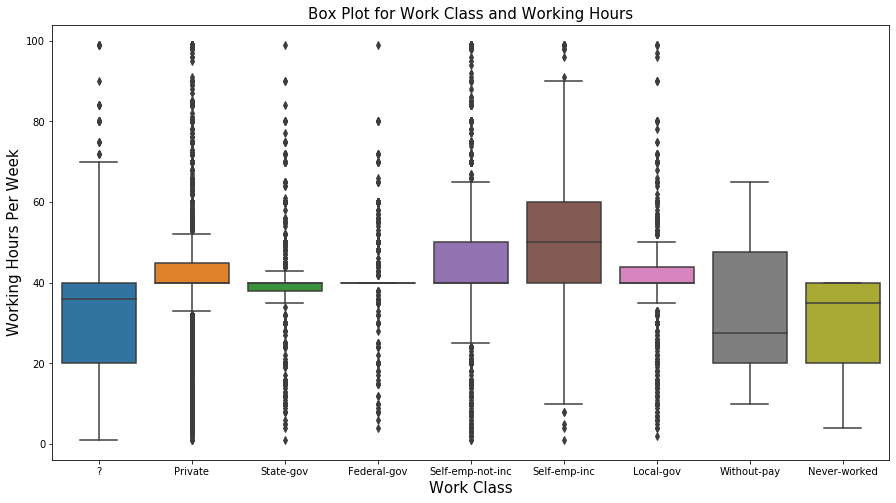

```python
# set the figure size
plt.figure(figsize=(15,8))

# plot a boxplot
sns.boxplot(x = 'workclass', y = 'hours.per.week', data = df_adult)

# add plot and axes labels
# set text size using 'fontsize'
plt.title('Box Plot for Work Class and Working Hours', fontsize = 15)
plt.xlabel('Work Class', fontsize = 15)
plt.ylabel('Working Hours Per Week', fontsize = 15)

# display the plot
plt.show()
```

We can infer that high proportion of the federal-gov employees have nearly 40 working hours per week. But, there are some federal-gov employees with working hours other than 40. Also, the working hours for individuals varies greatly depending upon their professions.

|  | **14. Compare the weightage based on demographic characteristics by gender** |
| --- | --- |

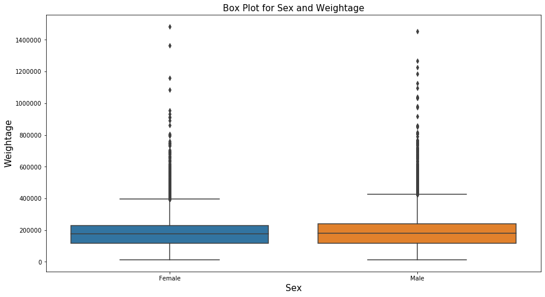

```python
# set the figure size
plt.figure(figsize = (15,8))

# plot a boxplot
sns.boxplot(x = 'sex', y = 'fnlwgt', data = df_adult)

# add plot and axes labels
# set text size using 'fontsize'
plt.title('Box Plot for Sex and Weightage',fontsize = 15)
plt.xlabel('Sex', fontsize = 15)
plt.ylabel('Weightage', fontsize = 15)

# display the plot
plt.show()
```

Gender does not impact the weightage based on demographic characteristics variable (Violinplot can also be used for this comparison).

## 3. Categorical and Categorical Analysis

|  | **15. Study the variation in income by gender** |
| --- | --- |

```python
# construct the crosstab
# fill in the cell values with their category-wise percentage using lambda function
income_table = pd.crosstab(index = df_adult["sex"], columns = df_adult["income"]).apply(lambda r: r/(r.sum()), axis=1)

# display the crosstab
income_table
```

| income sex | <=50K | >50K |
| --- | --- | --- |
| Female | 0.890539 | 0.109461 |
| Male | 0.694263 | 0.305737 |

Approximately 20% of males have high income (above 50k) compared to females.

|  | **16. Compare the income by race** |
| --- | --- |

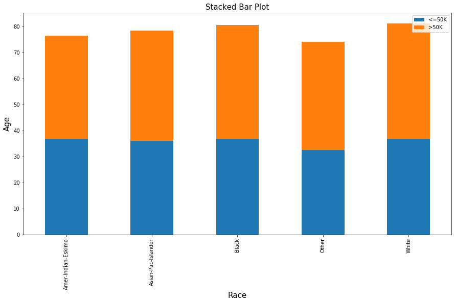

```python
# construct the pivot table to calculate average income
stack = pd.pivot_table(df_adult,index=["race"], columns=["income"], values='age', aggfunc='mean')

# plot the stacked bar graph
# 'stacked=True' returns the stacked bar plot
# set figure size using 'figsize'
fig = stack.plot.bar(stacked=True, figsize=(15,8))

# set axes labels
plt.title('Stacked Bar Plot', fontsize = 15)
fig.set_xlabel('Race', fontsize = 15)
fig.set_ylabel('Age', fontsize = 15)

# set the position of legend
fig.legend(loc='upper right')

# display the plot
plt.show()
```

Race has no impact over the income.

|  | **17. Is there an all male profession according to the data?** |
| --- | --- |

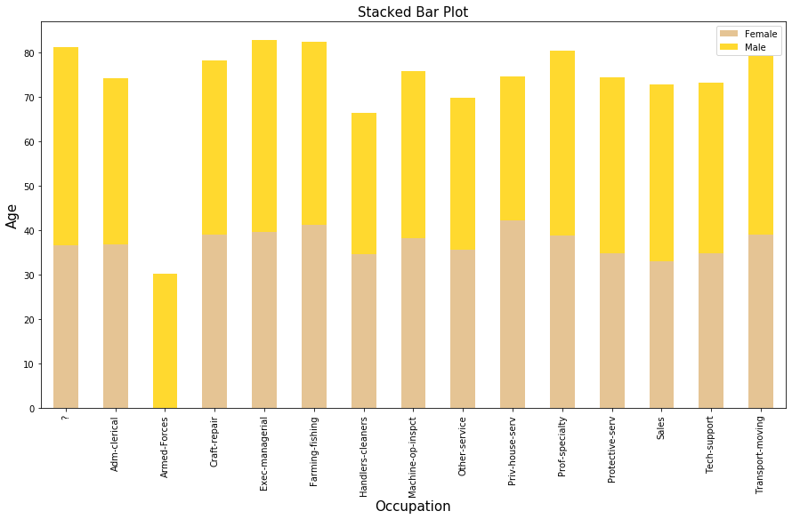

```python
# construct the pivot table
stack = pd.pivot_table(df_adult,index=["occupation"], columns=["sex"], values='age', aggfunc='mean')

# set the colors to the plot
color = sns.set_palette('Set2_r')

# plot the stacked bar graph
# set the figure size using 'figsize'
# 'stacked=True' returns stacked bar plot
# set the colors using 'color'
fig=stack.plot.bar(stacked=True, figsize=(15,8), colors = color)

# set the axes and plot labels
plt.title('Stacked Bar Plot', fontsize = 15)
fig.set_xlabel('Occupation', fontsize = 15)
fig.set_ylabel('Age', fontsize = 15)

# set position of legend
fig.legend(loc='upper right')

# display the plot
plt.show()
```

According to the data Armed-forces have no females employed.

|  | **18. How does income vary with working class?** |
| --- | --- |

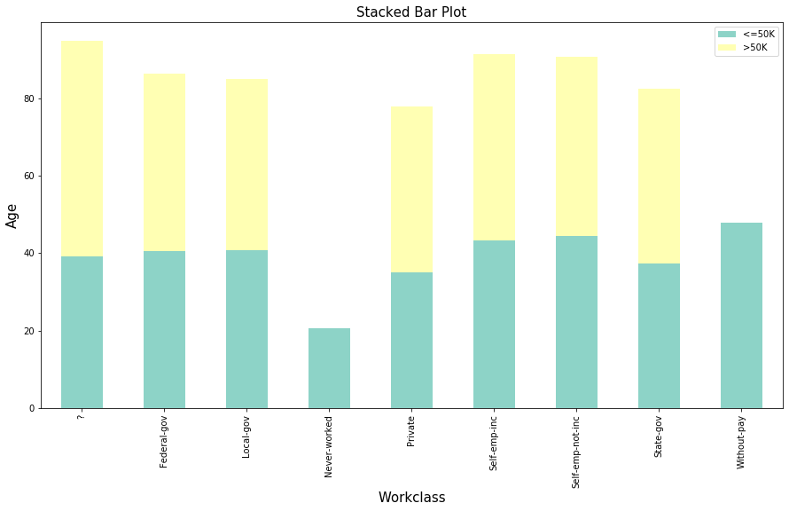

```python
# construct the pivot table
stack = pd.pivot_table(df_adult,index=["workclass"], columns=["income"], values='age', aggfunc='mean')

# set the colors to the plot
color = sns.set_palette('Set3')

# plot the stacked bar graph
fig=stack.plot.bar(stacked=True, figsize=(15,8), colors = color)

# set the axes and plot labels
plt.title('Stacked Bar Plot', fontsize = 15)
fig.set_xlabel('Workclass', fontsize = 15)
fig.set_ylabel('Age', fontsize = 15)

# set position of legend
fig.legend(loc='upper right')

# display the plot
plt.show()
```

The two classes which include people who have never worked and people working without pay have all members with earnings less than 50k, hence they are represented with a single colour in the plot.

|  | **19. How is income related to marital status?** |
| --- | --- |

```python
# construct the crosstab
income_table=pd.crosstab(index=df_adult["income"],columns=df_adult["marital.status"])

# display the crosstab
income_table
```

| marital.status income | Divorced | Married-AF-spouse | Married-civ-spouse | Married-spouse-absent | Never-married | Separated | Widowed |
| --- | --- | --- | --- | --- | --- | --- | --- |
| <=50K | 3980 | 13 | 8284 | 384 | 10192 | 959 | 908 |
| >50K | 463 | 10 | 6692 | 34 | 491 | 66 | 85 |

People who have never been married have large number of members who earn less than 50k, this makes sense as probably large proportion of people in this category are less aged.

|  | **20. Compare the income for different occupations** |
| --- | --- |

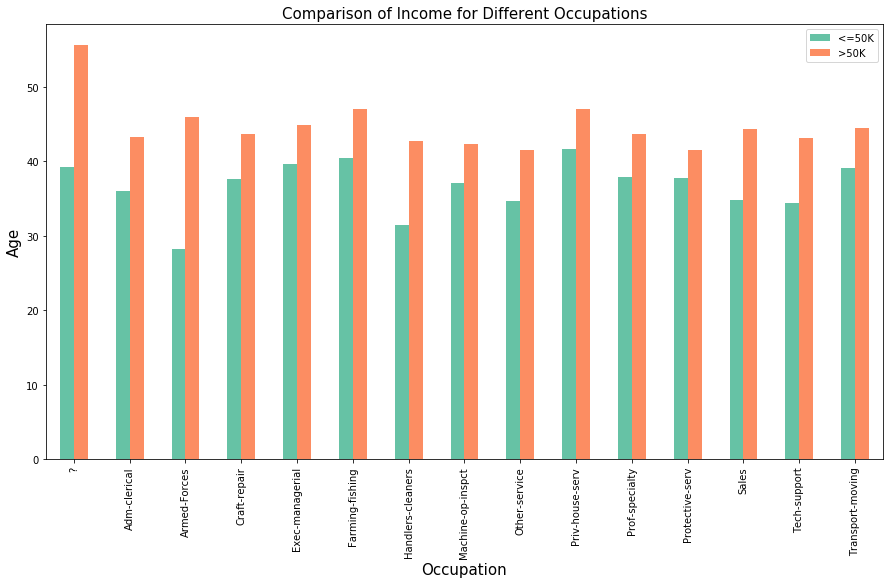

```python
# construct the pivot table
count = pd.pivot_table(df_adult,index=["occupation"], columns=["income"], values='age', aggfunc='mean')

# set the colors to the plot
color = sns.set_palette('Set2')

# plot the side-by-side bar plot
# set the figure size using 'figsize'
fig = count.plot.bar(figsize=(15,8), colors = color)

# set the axes and plot labels
plt.title('Comparison of Income for Different Occupations', fontsize = 15)
fig.set_xlabel('Occupation', fontsize = 15)
fig.set_ylabel('Age', fontsize = 15)

# set the position of legend
fig.legend(loc='upper right')

# display the plot
plt.show()
```

There is a significant difference in the income for individuals in armed forces. Also, the '?' indicates that the occupation is missing.